# Tarea 2 Especializacion en estadistica aplicada

- Nombre: Mateo Orozco Baldovino
- Especialidad en Estadistica Aplicada UTB

### Caracteristicas del entorno de desarrollo:

- Para el presente trabajo yo agarre el dataset desde este link (https://archive.ics.uci.edu/dataset/222/bank+marketing).
- Estoy realizando el analisis de este dataset usando python en visual studio code y jupyter notebook.
- Para las librerias utilizo un entorno virtual creado con conda.

Esta tarea puede ser encontrada en este repositorio [Github](https://github.com/TheMaorba/DataMining.git)

La base de datos utilizada es acerca de una institucion bancaria portuguesa que realizo unas campañas de marketing directo utilizando llamadas telefonicas.

El objetivo de clasificación es predecir si el cliente suscribirá o no un depósito El articulo puede ser encontrado en este link: https://repositorio.iscte-iul.pt/bitstream/10071/9499/5/dss_v3.pdf

## Punto 1: Descargue y cargue los datos en su notebook, usando Pandas preferiblemente. Imprima para tener una idea de los datos.

```python
import respuestas as rp
import pandas as pd
import numpy as np
# Importando la base de datos
df0 = pd.read_csv(r"D:\Documentos\Especialidad\DataMining\Tarea2\Dataset\bank.csv", sep=";")
# Ver tipo de datos en las columnas
df0.dtypes
```

```
age           int64
job          object
marital      object
education    object
default      object
balance       int64
housing      object
loan         object
contact      object
day           int64
month        object
duration      int64
campaign      int64
pdays         int64
previous      int64
poutcome     object
y            object
dtype: object
```

## Punto 2: Calcule la cantidad de datos faltantes y luego si no tiene cree artificialmente datos faltantes.

```python
print(f"La cantidad de datos faltantes inicialmente es de: {df0.isna().sum().sum()}")
from faltantes import GestorFaltantes
# Este codigo inserta los datos faltantes o NA y le asigna un nuevo nombre
df_conna = GestorFaltantes.insertar_nans(df0)
# Esta funcion muestra la cantidad de datos faltantes creados en el dataframe
GestorFaltantes.mostrar_nans(df_conna)
"""
En este codigo copio del df original para que no se modifique al momento de realizar los
cambios
"""
# Para los modelos normales
df1 = df_conna.copy()
# Para KNN
df2 = df_conna.copy()
```

```
La cantidad de datos faltantes inicialmente es de: 0
======================================================================
📊 Dataset: 45211 filas × 17 columnas
🔎 Valores totales: 768587
❌ NaNs totales: 153714 (20.0%)
======================================================================

NaNs por columna:

Columna                   | NaNs       | % NaNs
----------------------------------------------------------------------
age                       | 9042       | 20.0
job                       | 9042       | 20.0
marital                   | 9042       | 20.0
education                 | 9042       | 20.0
default                   | 9042       | 20.0
balance                   | 9042       | 20.0
housing                   | 9042       | 20.0
loan                      | 9042       | 20.0
contact                   | 9042       | 20.0
day                       | 9042       | 20.0
month                     | 9042       | 20.0
duration                  | 9042       | 20.0
campaign                  | 9042       | 20.0
pdays                     | 9042       | 20.0
previous                  | 9042       | 20.0
poutcome                  | 9042       | 20.0
y                         | 9042       | 20.0
======================================================================
```

## Punto 3: Use las metodologías vistas en clase para rellenar, o poner, datos en los lugares de los datos faltantes.

All the techniques to handle missing values

- Mean/Median/Mode replacement
- Random Sample Imputation
- Capturing NAN values with a new feature
- End of Distribution Imputation
- Arbitrary Imputation
- Frequent Categories Imputation

### Manejar datos faltantes mediante la eliminacion

```python
# Voy a realizar unos cambios para eliminar columnas innecesarias
df1 = df1.drop([
    "housing","day","loan","contact","month", "duration",
    "campaign", "pdays", "previous", "poutcome", "y"], axis=1)
# Este codigo lo realizo para realizar la eliminacion de los datos faltantes
df_drop = df1.dropna(axis=0)
print(f"La cantidad de datos faltantes actual en la base de datos es de: {df_drop.isna().sum().sum()}")
```

```
La cantidad de datos faltantes actual en la base de datos es de: 0
```

### Manejar datos faltantes imputando datos con un valor fijo o aleatorio

```python
# Este codigo crea la columna age_random_fixed
GestorFaltantes.impute_nan_random(df1,"age",1)
print(f"""
      La cantidad de datos faltantes en la nueva columna creada es de:
      {df1['age_random_fixed'].isna().sum().sum()}
      """)
```

```
      La cantidad de datos faltantes en la nueva columna creada es de:
      0
```

## Manejar datos faltantes mediante imputacion por la media o mediana

```python
from faltantes import GestorFaltantes
# Este codigo crea la columna age_mean
GestorFaltantes.impute_nan_meanmedian(df1, "age", "mean")
# Este codigo crea la columna age_median
GestorFaltantes.impute_nan_meanmedian(df1, "age", "median")
# Hasta este punto estan creadas las columnas age_random_fixed, age_mean y age_median
print(f"La cantidad de datos faltantes en la nueva columna age_mean es de: \
      {df1['age_mean'].isna().sum().sum()}")
print(f"La cantidad de datos faltantes en la nueva columna age_median es de: \
      {df1['age_median'].isna().sum().sum()}")
```

```
La cantidad de datos faltantes en la nueva columna age_mean es de:       0
La cantidad de datos faltantes en la nueva columna age_median es de:       0
```

### Mediante KNN

```
La cantidad de datos faltantes en el nuevo df es de: 90420
======================================================================
📊 Dataset: 45211 filas × 17 columnas
🔎 Valores totales: 768587
❌ NaNs totales: 90420 (11.76%)
======================================================================

NaNs por columna:

Columna                   | NaNs       | % NaNs
----------------------------------------------------------------------
age                       | 0          | 0.0
job                       | 9042       | 20.0
marital                   | 9042       | 20.0
education                 | 9042       | 20.0
default                   | 9042       | 20.0
balance                   | 0          | 0.0
housing                   | 9042       | 20.0
loan                      | 9042       | 20.0
contact                   | 9042       | 20.0
day                       | 0          | 0.0
month                     | 9042       | 20.0
duration                  | 0          | 0.0
campaign                  | 0          | 0.0
pdays                     | 0          | 0.0
previous                  | 0          | 0.0
poutcome                  | 9042       | 20.0
y                         | 9042       | 20.0
======================================================================
```

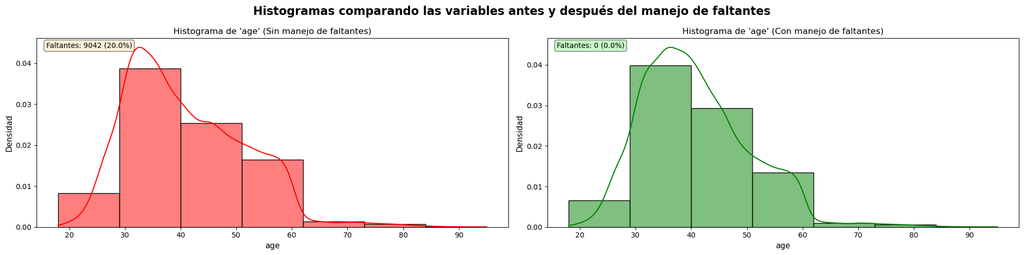

```
La media es: 40.80
La mediana es: 39.20
La desviacion estandar es: 9.71
La varianza es: 94.22
El rango es igual a: 77.00
La asimetria es de: 0.76
La curtosis es de: 0.90
```

```python
from faltantes import GestorFaltantes
from graficos import Graficos
"""
Este codigo crea un nuevo dataframe df_KNN donde utiliza K neibors para asignar na
segun los valores cercanos
"""
df_KNN = GestorFaltantes.knn_imputer_dataframe(df2)
print(f"La cantidad de datos faltantes en el nuevo df es de: {(df_KNN.isna().sum().sum())}")
GestorFaltantes.mostrar_nans(df_KNN)
Graficos.comparar_histogramas(
    df_original=df_conna,
    df_procesado=df_KNN,
    columna_original='age',
    columna_procesada='age'
)
Graficos.estadisticas(df_KNN, 'age')
```

- A diferencia de los métodos de imputación determinísticos simples, KNN no genera un pico tan extremo.
- Utiliza información de registros similares (vecinos) para imputar, siendo más sofisticado que media/mediana
- Curtosis moderada (0.90) indica menor concentración que media/mediana

## Punto 4: Haga gráficos para evaluar la calidad de este llenado y las formas de las distribuciones.

### Evaluando el manejo de faltantes mediante asignacion aleatoria

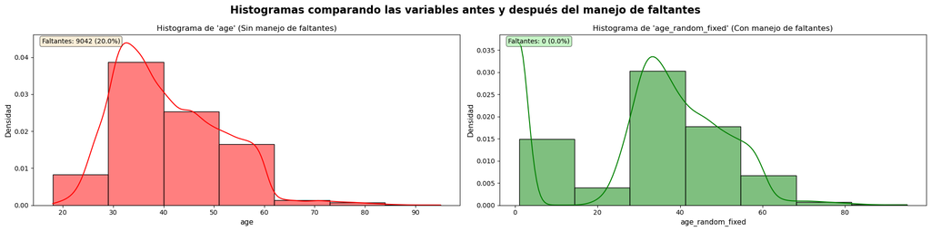

```
La media es: 32.95
La mediana es: 36.00
La desviacion estandar es: 18.58
La varianza es: 345.34
El rango es igual a: 94.00
La asimetria es de: -0.51
La curtosis es de: -0.47
```

```python
from graficos import Graficos
# Hasta este punto estan creadas las columnas age_random_fixed, age_mean y age_median
Graficos.comparar_histogramas(
    df_original=df_conna,
    df_procesado=df1,
    columna_original='age',
    columna_procesada='age_random_fixed'
)
Graficos.estadisticas(df1, 'age_random_fixed')
```

Teniendo en cuenta la utilización de métodos para el rellenado de los datos faltantes en la columna age podemos destacar diferentes características según el método utilizado: Histograma original: El histograma nos muestra que se generaron 9042 datos faltantes en la columna age que representa un 20% del total de los registros en esa columna. A su vez se nos muestra que los datos presentan una cola hacia la derecha lo que significa que los valores mas altos de edad presentan una menor frecuencia (asimetría positiva) y existen pocos casos con edades altas pero los hay También es unimodal debido a que presenta un solo pico que es entre los 30 y 40 años

### Evaluando metodo de imputacion por mediana

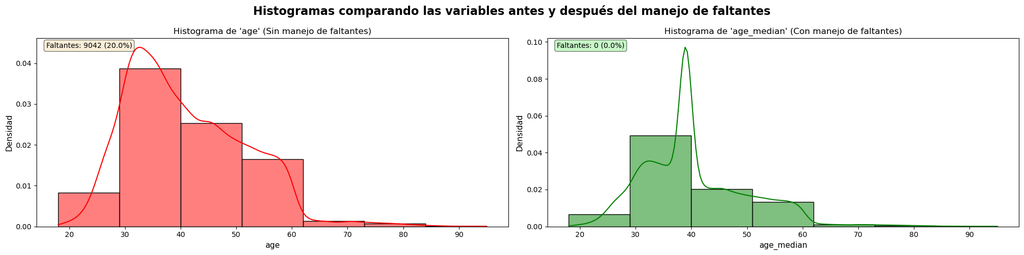

```
La media es: 40.94
La mediana es: 39.00
La desviacion estandar es: 10.62
La varianza es: 112.71
El rango es igual a: 77.00
La asimetria es de: 0.69
La curtosis es de: 0.34
Age_Median
La media es: 40.55
La mediana es: 39.00
La desviacion estandar es: 9.53
La varianza es: 90.76
El rango es igual a: 77.00
La asimetria es de: 0.89
La curtosis es de: 1.26
```

```python
Graficos.comparar_histogramas(
    df_original=df_conna,
    df_procesado=df1,
    columna_original='age',
    columna_procesada='age_median'
)
print("Age")
Graficos.estadisticas(df1, 'age')
print("Age_Median")
Graficos.estadisticas(df1, 'age_median')
```

### Evaluando metodo de imputacion por media

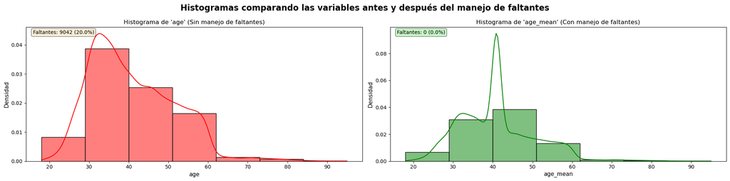

```
La media es: 40.94
La mediana es: 40.94
La desviacion estandar es: 9.50
La varianza es: 90.16
El rango es igual a: 77.00
La asimetria es de: 0.77
La curtosis es de: 1.18
```

```python
Graficos.comparar_histogramas(
    df_original=df_conna,
    df_procesado=df1,
    columna_original='age',
    columna_procesada='age_mean'
)

Graficos.estadisticas(df1, 'age_mean')
```

### Evaluando manejo mediante la eliminacion

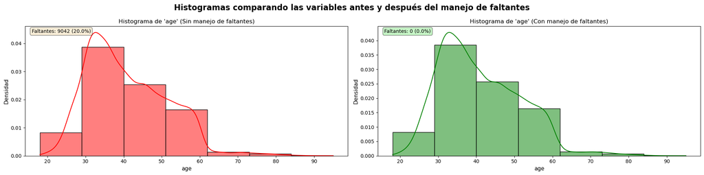

```
La media es: 41.00
La mediana es: 39.00
La desviacion estandar es: 10.60
La varianza es: 112.36
El rango es igual a: 77.00
La asimetria es de: 0.68
La curtosis es de: 0.28
```

```python
Graficos.comparar_histogramas(
    df_original=df_conna,
    df_procesado=df_drop,
    columna_original='age',
    columna_procesada='age'
)

Graficos.estadisticas(df_drop, 'age')
```

## Punto 6: Determine si tiene datos outliers o datos extremos y diga cuales son y elimínelos. La información para esta tarea está en el primer notebook.

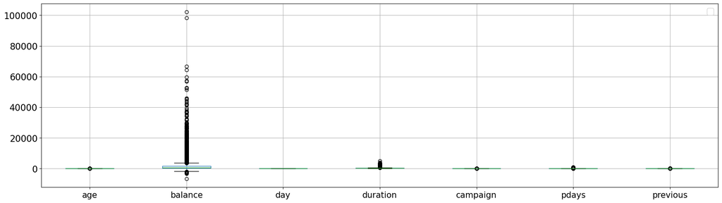

```python
Graficos.ver_outliers (df_KNN)
```

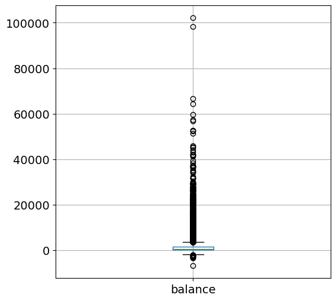

```python
Graficos.ver_outliers_columna(df_KNN, "balance")
```

Intente la eliminacion de outliers pero teniendo en cuenta que se trata de balance de dinero en cuentas bancarias note que la informacion actual no presentaba un problema por lo que decidi continuar con estos datos.

## Punto 7: Adicionalmente use los algoritmos que encontrará en el segundo notebook (linear_regresion) para inferir regresiones, determine parámetros, determine el grado de regresión o coeficiente de regresión (bondad de ajuste) y escriba conclusiones.

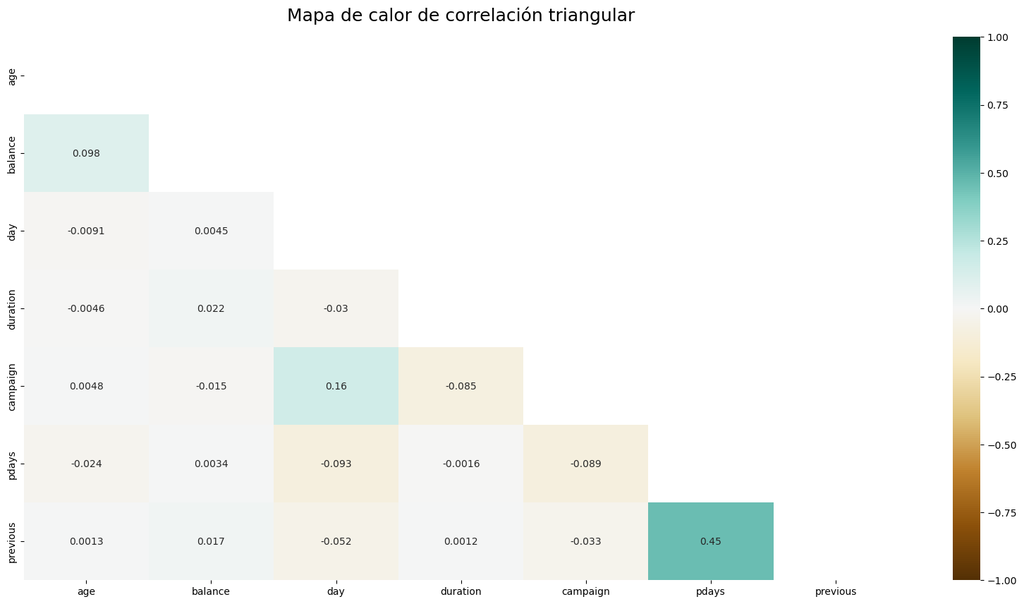

```python
from regresiones import Inferencia
Inferencia.correlation_heatmap(df0)
```

- La correlacion mas fuerte se presenta en pdays (Clientes con más contactos previos tienen más días desde el último contacto lo que es una relación lógica y esperada en campañas de marketing)
- age/balance significa que personas mayores tienden a tener saldos mas altos
- Relacion muy debil o inexistente entre el resto de las variables debido a valores de r bajos

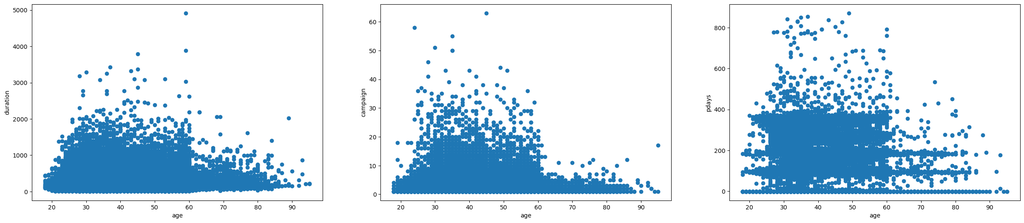

```python
import matplotlib.pyplot as plt

plt.figure(figsize=(30,6))

# Edad vs duración de la llamada
plt.subplot(131)
plt.scatter(df0["age"], df0["duration"])
plt.xlabel("age")
plt.ylabel("duration")

# Edad vs número de contactos en la campaña actual
plt.subplot(132)
plt.scatter(df0["age"], df0["campaign"])
plt.xlabel("age")
plt.ylabel("campaign")

# Edad vs días desde el último contacto previo
plt.subplot(133)
plt.scatter(df0["age"], df0["pdays"])
plt.xlabel("age")
plt.ylabel("pdays")

plt.show()
```

Gráfico 1: Age vs Duration

- Concentración masiva cerca de cero: La mayoría de las llamadas tienen duración < 500 segundos
- Distribución independiente de la edad: El patrón de dispersión es similar en todos los rangos etarios
- No existe relación clara entre edad y duración de llamadas
- La duración está más relacionada con el interés del cliente que con su edad Gráfico 2: Age vs Campaign
- Banda horizontal densa: Gran acumulación de puntos en el rango 1-30 contactos
- Outliers extremos: Algunos casos con 60+ contactos, principalmente en edades medias (30-60 años)
- La edad no determina cuántas veces se contacta a un cliente
- Patrones similares en todos los grupos etarios Gráfico 3: Age vs Pdays
- Los días desde el último contacto no dependen de la edad del cliente
- La edad no es un predictor útil para estas variables de comportamiento
- Bandas horizontales: Sugieren campañas previas en momentos específicos (hace 200 y 400 días)

## Calculo de intercepto, pendiente y error estandar

### Using optimize.leastsq

```python
from scipy import optimize
import random
def f( x, p0, p1):
    return p0+p1*x

def ff(x, p):
    return f(x, *p)

def fit_leastsq(p0, datax, datay, function):

    errfunc = lambda p, x, y: function(x,p) - y

    pfit, pcov, infodict, errmsg, success = optimize.leastsq(errfunc, p0, args=(datax, datay), full_output=1, epsfcn=0.0001)

    if (len(datay) > len(p0)) and pcov is not None:
        s_sq = (errfunc(pfit, datax, datay)**2).sum()/(len(datay)-len(p0))
        pcov = pcov * s_sq
    else:
        pcov = np.inf

    error = []
    for i in range(len(pfit)):
        try:
            error.append(np.absolute(pcov[i][i])**0.5)
        except:
            error.append( 0.00 )
    pfit_leastsq = pfit
    perr_leastsq = np.array(error)
    return pfit_leastsq, perr_leastsq

# These are the true parameters
p0,p1 = 1.0, 1.0
# These are initial guesses for fits:
pstart = [p0+random.random(),p1+random.random()]
pfit, perr = fit_leastsq(pstart, df0["age"], df0["duration"], ff)

print("\n# Fit parameters and parameter errors from lestsq method :")
print("pfit = ", pfit)
print("perr = ", perr)
```

```
# Fit parameters and parameter errors from lestsq method :
pfit =  [ 2.62777998e+02 -1.12734386e-01]
perr =  [4.82370889 0.11405993]
```

### Using optimize.curve_fit

```python
err_stdev = 0.2
def fit_curvefit(p0, datax, datay, function, yerr=err_stdev, **kwargs):
    """
    Note: As per the current documentation (Scipy V1.1.0), sigma (yerr) must be:
        None or M-length sequence or MxM array, optional
    Therefore, replace:
        err_stdev = 0.2
    With:
        err_stdev = [0.2 for item in xdata]
    Or similar, to create an M-length sequence for this example.
    """
    pfit, pcov = optimize.curve_fit(f,datax,datay,p0=p0, sigma=None, epsfcn=0.0001, **kwargs)
    error = []
    for i in range(len(pfit)):
        try:
            error.append(np.absolute(pcov[i][i])**0.5)
        except:
            error.append( 0.00 )
    pfit_curvefit = pfit
    perr_curvefit = np.array(error)
    return pfit_curvefit, perr_curvefit

pfit, perr = fit_curvefit(pstart, df0["age"], df0["duration"], ff)

print("\n# Fit parameters and parameter errors from curve_fit method :")
print("pfit = ", pfit)
print("perr = ", perr)
```

```
# Fit parameters and parameter errors from curve_fit method :
pfit =  [ 2.62777998e+02 -1.12734386e-01]
perr =  [4.82370889 0.11405993]
```

### Using bootstrap

```python
def fit_bootstrap(p0, datax, datay, function, yerr_systematic=0.0):

    errfunc = lambda p, x, y: function(x,p) - y

    # Fit first time
    pfit, perr = optimize.leastsq(errfunc, p0, args=(datax, datay), full_output=0)


    # Get the stdev of the residuals
    residuals = errfunc(pfit, datax, datay)
    sigma_res = np.std(residuals)

    sigma_err_total = np.sqrt(sigma_res**2 + yerr_systematic**2)

    # 100 random data sets are generated and fitted
    ps = []
    for i in range(100):

        randomDelta = np.random.normal(0., sigma_err_total, len(datay))
        randomdataY = datay + randomDelta
        randomfit, randomcov = optimize.leastsq(errfunc, p0, args=(datax, randomdataY), full_output=0)
        ps.append(randomfit)

    ps = np.array(ps)
    mean_pfit = np.mean(ps,0)

    # You can choose the confidence interval that you want for your
    # parameter estimates:
    Nsigma = 1. # 1sigma gets approximately the same as methods above
                # 1sigma corresponds to 68.3% confidence interval
                # 2sigma corresponds to 95.44% confidence interval
    err_pfit = Nsigma * np.std(ps,0)

    pfit_bootstrap = mean_pfit
    perr_bootstrap = err_pfit
    return pfit_bootstrap, perr_bootstrap

pfit, perr = fit_bootstrap(pstart, df0["age"], df0["duration"], ff)

print("\n# Fit parameters and parameter errors from bootstrap method :")
print("pfit = ", pfit)
print("perr = ", perr)
```

```
# Fit parameters and parameter errors from bootstrap method :
pfit =  [ 2.61591720e+02 -8.56670156e-02]
perr =  [5.00341086 0.11852249]
```

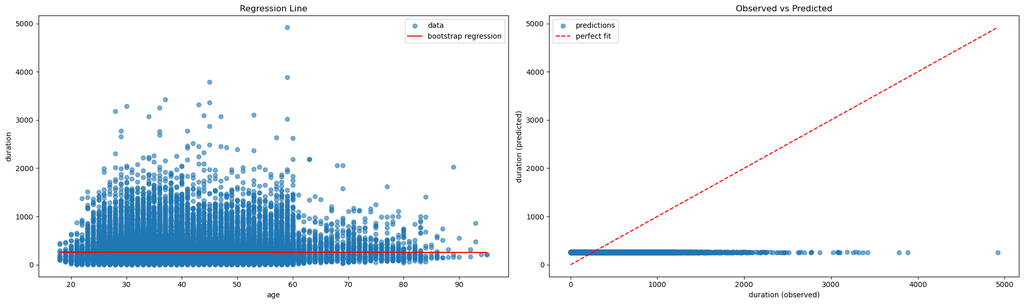

```python
plt.figure(figsize=(20,6))

# Subplot 1: Datos originales con línea de regresión
plt.subplot(121)  # Cambiado a 121 si solo usas 2 gráficos
plt.scatter(df0['age'], df0['duration'], label="data", alpha=0.6)
x0 = df0['age']
plt.plot(x0, f(x0, *pfit), color="r", label="bootstrap regression")
plt.xlabel("age")
plt.ylabel("duration")
plt.legend()
plt.title("Regression Line")

# Subplot 2: Observado vs Predicho
plt.subplot(122)
y_pred = f(df0['age'], *pfit)  # Predicciones usando age
plt.scatter(df0['duration'], y_pred, label="predictions", alpha=0.6)

# Línea de ajuste perfecto
dmin = min(df0['duration'].min(), y_pred.min())
dmax = max(df0['duration'].max(), y_pred.max())
plt.plot([dmin, dmax], [dmin, dmax], color="r", linestyle="--", label="perfect fit")

plt.xlabel("duration (observed)")
plt.ylabel("duration (predicted)")
plt.legend()
plt.title("Observed vs Predicted")

plt.tight_layout()
plt.show()
```

Gráfico izquierdo (Regression Line)

- La nube de puntos muestra muchísima dispersión de duration para casi cualquier age, con muchos valores altos (outliers) y varianza creciente/irregular, lo que indica que la relación no es bien explicada por una recta simple.
- La línea roja (“bootstrap regression”) es casi horizontal, lo que implica que el coeficiente de age (pendiente) estimado es cercano a 0: el modelo termina prediciendo un valor casi constante de duration sin importar la edad. Gráfico derecho (Observed vs Predicted)
- Si el modelo predijera bien, los puntos caerían cerca de la diagonal roja punteada (ajuste perfecto); aquí la mayoría de puntos se agrupan en una franja horizontal alrededor de un valor predicho casi constante, lejos de la diagonal.
- Eso significa que para duraciones observadas grandes (por ejemplo 1000–5000), el modelo sigue prediciendo valores bajos similares, generando errores grandes y sesgo (subestima sistemáticamente los valores altos).

```python
from sklearn.metrics import r2_score
r2 = r2_score(df0["duration"], f(x0,*pfit))
print('r2 score for perfect model is', r2)
```

```
r2 score for perfect model is 2.0269939057460107e-05
```

```python
def r2_hand(y,yhat):
    SST=np.sum((y-np.mean(y))**2)
    SSE=np.sum((y-yhat)**2)
    R2=(SST-SSE)/SST
    return R2
print('r2 score for perfect model is', r2_hand(df0["duration"], f(x0,*pfit)))
```

```
r2 score for perfect model is 2.0269939057421723e-05
```

Un R2 tan cercano a 0 indica que el modelo explica casi nada de la variabilidad de duration en la practica.

```python
import statsmodels.api as sm
from statsmodels.tools.eval_measures import rmse
from statsmodels.stats.outliers_influence import variance_inflation_factor

X = df0['age']   # independent variables
y = df0['duration']   # dependent variables

# to get intercept -- this is optional
X = sm.add_constant(X)

# fit the regression model
reg = sm.OLS(y, X).fit()
reg.summary()
```

OLS Regression Results

| Dep. Variable: | duration | R-squared: | 0.000 |
| --- | --- | --- | --- |
| Model: | OLS | Adj. R-squared: | -0.000 |
| Method: | Least Squares | F-statistic: | 0.9769 |
| Date: | Fri, 16 Jan 2026 | Prob (F-statistic): | 0.323 |
| Time: | 01:16:00 | Log-Likelihood: | -3.1512e+05 |
| No. Observations: | 45211 | AIC: | 6.302e+05 |
| Df Residuals: | 45209 | BIC: | 6.303e+05 |
| Df Model: | 1 |  |  |
| Covariance Type: | nonrobust |  |  |

|  | coef | std err | t | P>\|t\| | [0.025 | 0.975] |
| --- | --- | --- | --- | --- | --- | --- |
| const | 262.7780 | 4.824 | 54.476 | 0.000 | 253.323 | 272.233 |
| age | -0.1127 | 0.114 | -0.988 | 0.323 | -0.336 | 0.111 |

| Omnibus: | 31837.535 | Durbin-Watson: | 1.906 |
| --- | --- | --- | --- |
| Prob(Omnibus): | 0.000 | Jarque-Bera (JB): | 695882.850 |
| Skew: | 3.145 | Prob(JB): | 0.00 |
| Kurtosis: | 21.162 | Cond. No. | 169. |

Notes:  
[1] Standard Errors assume that the covariance matrix of the errors is correctly specified.

- El R-squared: 0.000 nos indica que la edad no explica la variabilidad de duration
- age ≈ -0.1127: por cada año adicional de edad, el modelo estima que duration baja ~0.11 unidades (según la unidad de duration), pero este efecto es minúsculo.
- Para age, el valor P>|t| = 0.323 (con t ≈ -0.988) indica que no hay evidencia estadística (a niveles típicos como 0.05) de que la edad tenga un efecto lineal distinto de 0 sobre duration.
- El intervalo de confianza 95% para age incluye 0 (aprox. de -0.336 a 0.111), reforzando que el efecto podría ser negativo, nulo o incluso positivo.
- Omnibus, Jarque-Bera, Skew y Kurtosis sugieren residuos muy alejados de normalidad (asimetría alta y colas pesadas), algo común cuando duration tiene outliers o distribución muy sesgada.

```python
X = df0[['age','previous',"balance","campaign"]]   # independent variables
y = df0['duration']   # dependent variables

# to get intercept -- this is optional
X = sm.add_constant(X)

# fit the regression model
reg = sm.OLS(y, X).fit()
reg.summary()
```

OLS Regression Results

| Dep. Variable: | duration | R-squared: | 0.008 |
| --- | --- | --- | --- |
| Model: | OLS | Adj. R-squared: | 0.008 |
| Method: | Least Squares | F-statistic: | 86.64 |
| Date: | Fri, 16 Jan 2026 | Prob (F-statistic): | 1.85e-73 |
| Time: | 01:16:00 | Log-Likelihood: | -3.1495e+05 |
| No. Observations: | 45211 | AIC: | 6.299e+05 |
| Df Residuals: | 45206 | BIC: | 6.300e+05 |
| Df Model: | 4 |  |  |
| Covariance Type: | nonrobust |  |  |

|  | coef | std err | t | P>\|t\| | [0.025 | 0.975] |
| --- | --- | --- | --- | --- | --- | --- |
| const | 281.4873 | 4.932 | 57.074 | 0.000 | 271.820 | 291.154 |
| age | -0.1527 | 0.114 | -1.337 | 0.181 | -0.376 | 0.071 |
| previous | -0.2133 | 0.524 | -0.407 | 0.684 | -1.241 | 0.814 |
| balance | 0.0018 | 0.000 | 4.455 | 0.000 | 0.001 | 0.003 |
| campaign | -7.0073 | 0.390 | -17.980 | 0.000 | -7.771 | -6.243 |

| Omnibus: | 32090.370 | Durbin-Watson: | 1.913 |
| --- | --- | --- | --- |
| Prob(Omnibus): | 0.000 | Jarque-Bera (JB): | 712854.564 |
| Skew: | 3.176 | Prob(JB): | 0.00 |
| Kurtosis: | 21.387 | Cond. No. | 1.36e+04 |

Notes:  
[1] Standard Errors assume that the covariance matrix of the errors is correctly specified.  
[2] The condition number is large, 1.36e+04. This might indicate that there are  
strong multicollinearity or other numerical problems.

- El modelo ahora es globalmente significativo (F-statistic = 86.64 con Prob(F-statistic) ≈ 1.85e-73), lo que indica que, en conjunto, al menos uno de esos predictores aporta información sobre duration.
- el poder explicativo sigue siendo muy bajo: R2=0.008 R2 =0.008 y R2 R2 ajustado = 0.008, o sea que el modelo solo explica ~0.8% de la variación de duration
- Diagnósticos del modelo: Omnibus y Jarque-Bera con p≈0, Skew ~3.176 y Kurtosis ~21.387 indican que los residuos no siguen normalidad
- El unico coeficiente que puede llegar a ser relevante seria el de campaign debido a que indica que a más contactos en la campaña, la duración esperada baja en promedio 7 unidades

```python
# importing train_test_split from sklearn
from sklearn.model_selection import train_test_split
# splitting the data
x_train, x_test, y_train, y_test = train_test_split(X, y, test_size = 0.2, random_state = 42)
```

```python
# importing module
from sklearn.linear_model import LinearRegression
# creating an object of LinearRegression class
LR = LinearRegression()
# fitting the training data
LR.fit(x_train,y_train)
```

```
LinearRegression()
```

```python
y_prediction =  LR.predict(x_test)
y_prediction
```

```
array([268.00272213, 265.78742922, 271.4005712 , ..., 263.98339652,
       261.3483315 , 265.06933041])
```

```python
# importing r2_score module
from sklearn.metrics import r2_score
from sklearn.metrics import mean_squared_error
# predicting the accuracy score
score=r2_score(y_test,y_prediction)
print("r2 score is ",score)
print("mean_sqrd_error is==",mean_squared_error(y_test,y_prediction))
print("root_mean_squared error of is==",np.sqrt(mean_squared_error(y_test,y_prediction)))
```

[output not shown]

- Se entrena un modelo de regresion linear para hacer las predicciones
- R2 sigue siendo bajo por lo que el modelo solo explica el 0.475% de la variacion por lo que no es significativo
- El mean_squared_error ≈ 67291 y el root_mean_squared_error (RMSE) ≈ 259.41 indican que el error típico de predicción está alrededor de 259 unidades de duration, que es alto si se compara con el nivel típico de predicción (~260); en la práctica, el modelo está fallando especialmente en valores grandes (colas/outliers), lo cual concuerda con los gráficos previos.
- El modelo refuerza la afirmacion que es dificil de predecir la variable duration

```python
y_prediction_all =  LR.predict(X)
```

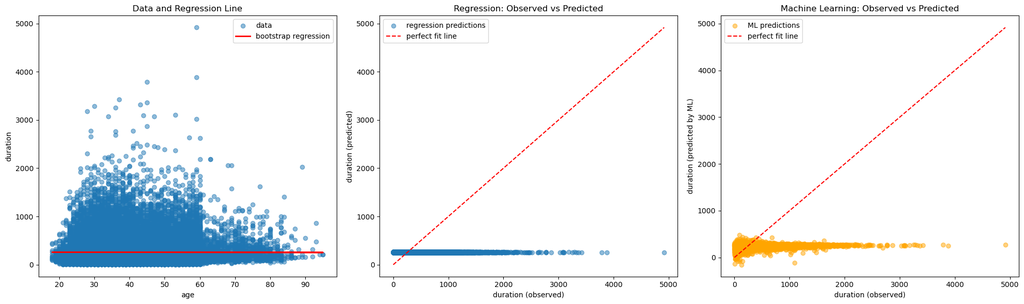

```python
plt.figure(figsize=(20,6))  # Ajustado el tamaño

# Gráfico 1: Datos originales con regresión
plt.subplot(131)
plt.scatter(df0['age'], df0['duration'], label="data", alpha=0.5)
x0 = df0['age']
plt.plot(x0, f(x0, *pfit), color="r", linewidth=2, label="bootstrap regression")
plt.xlabel("age")
plt.ylabel("duration")
plt.legend()
plt.title("Data and Regression Line")

# Gráfico 2: Valores observados vs predichos (regresión)
plt.subplot(132)
y_pred_regression = f(df0['age'], *pfit)  # Predicciones de la regresión
plt.scatter(df0['duration'], y_pred_regression, label="regression predictions", alpha=0.5)
plt.plot([df0['duration'].min(), df0['duration'].max()],
         [df0['duration'].min(), df0['duration'].max()],
         color="r", linestyle="--", label="perfect fit line")
plt.xlabel("duration (observed)")
plt.ylabel("duration (predicted)")
plt.legend()
plt.title("Regression: Observed vs Predicted")

# Gráfico 3: Valores observados vs predichos (ML)
plt.subplot(133)
plt.scatter(y, y_prediction_all, color="orange", alpha=0.5, label="ML predictions")
plt.plot([y.min(), y.max()], [y.min(), y.max()],
         color="r", linestyle="--", label="perfect fit line")
plt.xlabel("duration (observed)")
plt.ylabel("duration (predicted by ML)")
plt.legend()
plt.title("Machine Learning: Observed vs Predicted")

plt.tight_layout()
plt.show()
```

Data and Regression Line

- La nube age vs duration tiene enorme dispersión y muchos valores extremos; en ese contexto, la línea roja (regresión/“bootstrap regression”) queda casi horizontal, señal de que el efecto lineal de age es muy pequeño comparado con el ruido. Esto implica que con solo age (o con una relación lineal simple) es difícil explicar la variación de duration. Regression: Observed vs Predicted
- En el gráfico de observados vs predichos para regresión, la mayoría de puntos forma una franja horizontal alrededor de un valor predicho casi constante, y casi ninguno sigue la diagonal punteada (ajuste perfecto). Esto significa que el modelo subestima sistemáticamente las duraciones altas: aunque el valor observado crezca hasta miles, la predicción se queda en cientos. Machine Learning: Observed vs Predicted
- El panel de ML muestra un patrón similar: hay algo más de variación en las predicciones (nube naranja más “gruesa”), pero sigue sin alinearse con la diagonal, por lo que no está modelando bien el crecimiento de duration cuando los observados son grandes. En la práctica, ambos modelos parecen “encogerse” hacia valores típicos y fallar en la cola derecha (outliers/cola pesada).

```python
# predicting the accuracy score
score=r2_score(y,y_prediction_all)
print("r2 score is ",score)
print("mean_sqrd_error is==",mean_squared_error(y,y_prediction_all))
print("root_mean_squared error of is==",np.sqrt(mean_squared_error(y,y_prediction_all)))
```

[output not shown]

- R² = 0.00756: el modelo solo explica ~0.756% de la variación de duration, es decir, prácticamente nada; es consistente con lo que se veía en los gráficos
- MSE = 65817.96: es el promedio del error al cuadrado
- RMSE = 256.55: es la raíz del MSE y se interpreta como un “error típico” en las mismas unidades de duration; en promedio, tus predicciones se desvían alrededor de 256 unidades
- El modelo lineal actual y/o las variables usadas no están capturando la estructura de duration debido a sus valores cercanos a 0.